# Estudios de Informática, Multimedia y Telecomunicaciones

# Minería de datos: PEC2 - Métodos no supervisados

Gloria Manresa

Mayo 2023

## 0.1 Ejercicio 1

### 0.1.1 Enunciado

Presenta el juego de datos, nombre y significado de cada columna, así como las distribuciones de sus valores.

Adicionalmente realiza un estudio similar al de los ejemplos 1.1 y 1.2.

- 10%. Se explican los campos de la base de datos
- 25%. Se aplica el algoritmo de k-means de forma correcta.
- 25%. Se prueban con diferentes valores de k.
- 10%. Se obtiene una medida de lo bueno que es el agrupamiento.
- 20%. Se describen e interpretan los diferentes clusters obtenidos.
- 10%. Se presenta el código y es fácilmente reproducible.

### 0.1.2 Descripción del origen del conjunto de los datos.

Los estudiantes y el profesorado del Cornell College en Mount Vernon, Iowa, recogieron datos durante muchos años en el mirador de halcones del lago MacBride, cerca de Iowa City, en el estado de Iowa. El conjunto de datos que analizamos aquí es un subconjunto del conjunto de datos original, utilizando sólo aquellas especies para las que había más de 10 observaciones. Los datos se recogieron en muestras aleatorias de tres especies diferentes de halcones: Colirrojo, Gavilán y Halcón de Cooper.

### 0.1.3 Carga de los datos

En un primer lugar cargamos los datos.

```r
if (!require('Stat2Data')) install.packages('Stat2Data')
library(Stat2Data)
data("Hawks")
```

A continuación presentamos los datos con el siguiente resumen informativo, dónde podemos ver los valores que toman cada una de las variables.

```r
summary(Hawks)
```

```
##      Month             Day             Year       CaptureTime   ReleaseTime
##  Min.   : 8.000   Min.   : 1.00   Min.   :1992   11:35  : 14          :842
##  1st Qu.: 9.000   1st Qu.: 9.00   1st Qu.:1995   13:30  : 14   11:00  :  2
##  Median :10.000   Median :16.00   Median :1999   11:45  : 13   11:35  :  2
##  Mean   : 9.843   Mean   :15.74   Mean   :1998   12:10  : 13   12:05  :  2
##  3rd Qu.:10.000   3rd Qu.:23.00   3rd Qu.:2001   14:00  : 13   12:50  :  2
##  Max.   :11.000   Max.   :31.00   Max.   :2003   13:05  : 12   13:32  :  2
##                                                  (Other):829   (Other): 56
##       BandNumber  Species  Age     Sex          Wing           Weight
##            :  2   CH: 70   A:224    :576   Min.   : 37.2   Min.   :  56.0
##  1142-09240:  1   RT:577   I:684   F:174   1st Qu.:202.0   1st Qu.: 185.0
##  1142-09241:  1   SS:261           M:158   Median :370.0   Median : 970.0
##  1142-09242:  1                            Mean   :315.6   Mean   : 772.1
##  1142-18229:  1                            3rd Qu.:390.0   3rd Qu.:1120.0
##  1142-19209:  1                            Max.   :480.0   Max.   :2030.0
##  (Other)   :901                            NA's   :1       NA's   :10
##      Culmen         Hallux            Tail        StandardTail
##  Min.   : 8.6   Min.   :  9.50   Min.   :119.0   Min.   :115.0
##  1st Qu.:12.8   1st Qu.: 15.10   1st Qu.:160.0   1st Qu.:162.0
##  Median :25.5   Median : 29.40   Median :214.0   Median :215.0
##  Mean   :21.8   Mean   : 26.41   Mean   :198.8   Mean   :199.2
##  3rd Qu.:27.3   3rd Qu.: 31.40   3rd Qu.:225.0   3rd Qu.:226.0
##  Max.   :39.2   Max.   :341.40   Max.   :288.0   Max.   :335.0
##  NA's   :7      NA's   :6                        NA's   :337
##      Tarsus        WingPitFat        KeelFat           Crop
##  Min.   :24.70   Min.   :0.0000   Min.   :0.000   Min.   :0.0000
##  1st Qu.:55.60   1st Qu.:0.0000   1st Qu.:2.000   1st Qu.:0.0000
##  Median :79.30   Median :1.0000   Median :2.000   Median :0.0000
##  Mean   :71.95   Mean   :0.7922   Mean   :2.184   Mean   :0.2345
##  3rd Qu.:87.00   3rd Qu.:1.0000   3rd Qu.:3.000   3rd Qu.:0.2500
##  Max.   :94.00   Max.   :3.0000   Max.   :4.000   Max.   :5.0000
##  NA's   :833     NA's   :831      NA's   :341     NA's   :343
```

Observamos que el juego de datos presenta 19 columnas y 908 observaciones. Los nombres y significados de las columnas son los siguientes:

- Month: Mes, toma valores desde 8 a 11.
- Day: Día del mes.
- Year: Año, toma valores desde 1992 hasta 2003.
- CaptureTime: Hora de la captura.
- ReleaseTime: Hora de la liberación.
- BandNumber: Identificación.
- Species: Código de una de las tres especies (CH=Cooper’s, RT=Red-tailed, SS=Sharp-Shinned).
- Age: Toma los valores A = Adult o I = Imature.
- Sex: Toma los valores F = Female o M = Male.
- Wing: Longitud (en mm) de la pluma principal del ala desde la punta hasta la muñeca a la que se une.
- Weight: Peso corporal (en gramos).
- Culmen: Longitud (en mm) del pico superior desde la punta hasta donde choca con la parte carnosa del ave.
- Hallux: Longitud (en mm) de la garra.
- Tail: Medida (en mm) relacionada con la longitud de la cola (inventada en el MacBride Raptor Center)
- StandardTail: Medida estándar de la longitud de la cola (en mm)
- Tarsus: Longitud del hueso básico de la pata (en mm).
- WingPitFat: Cantidad de grasa en la ala.
- KeelFat: Cantidad de grasa en el esternón (medida al tacto).
- Crop: Cantidad de material en el cultivo, codificado de 1=lleno a 0=vacío.

### 0.1.4 Limpieza de los datos

Las variables numéricas en las que se basará el siguiente estudio son: Wing, Weight, Culmen, Hallux. A continuación mostramos el porcentaje de valores NA que tienen dichas variables:

```r
# Porcentaje valores NA
sort(colMeans(is.na(Hawks[,10:13])), decreasing = TRUE)*100
```

```
##    Weight    Culmen    Hallux      Wing
## 1.1013216 0.7709251 0.6607930 0.1101322
```

```r
# Registros valores NA
colSums(is.na(Hawks[,10:13]))
```

```
##   Wing Weight Culmen Hallux
##      1     10      7      6
```

Dado que los porcentajes son muy bajos, menos del 1’2% se decide borrarlos.

Guardamos en una nueva variable el subconjunto de los datos que incluya únicamente las cuatro variables numéricas con las que vamos a trabajar y elimina los registros que contienen Na’s.

```r
x <- na.omit(Hawks[,10:13])
```

Antes de proceder con el estudio escalamos los datos de las variables a utilizar para que todas tengan el mismo peso en el algoritmo.

```r
x_scale <- scale(x)
```

### 0.1.5 Método de agregación k-means

A continuación vamos a utilizar el método de agregación k-means sobre el data set “Hawks” presentado anteriormente.

El objetivo del ejercicio es encontrar agrupaciones para predecir la columna “Species”. Se realizará con el método no supervisado de agregación k-means por lo que no se utilizará dicha columna en el estudio.

Trabajaremos únicamente con las variables numéricas: Wing, Weight, Culmen, Hallux.

Hay que tener en cuenta que teóricamente no conocemos el número óptimo de clústers por lo que probaremos con varios valores.

```r
library(cluster)
set.seed(3)

d <- daisy(x_scale)
resultados <- rep(0, 10)
for (i in c(2,3,4,5,6,7,8,9,10))
{
  fit           <- kmeans(x_scale, i)
  y_cluster     <- fit$cluster
  sk            <- silhouette(y_cluster, d)
  resultados[i] <- mean(sk[,3])
}

resultados[2:10]
```

```
## [1] 0.7728399 0.7870581 0.5353183 0.5110736 0.4727849 0.4018636 0.3616606
## [8] 0.3861249 0.3843435
```

Mostramos en un gráfica los valores de las siluetas media de cada prueba para comprobar que número de clústers es el mejor.

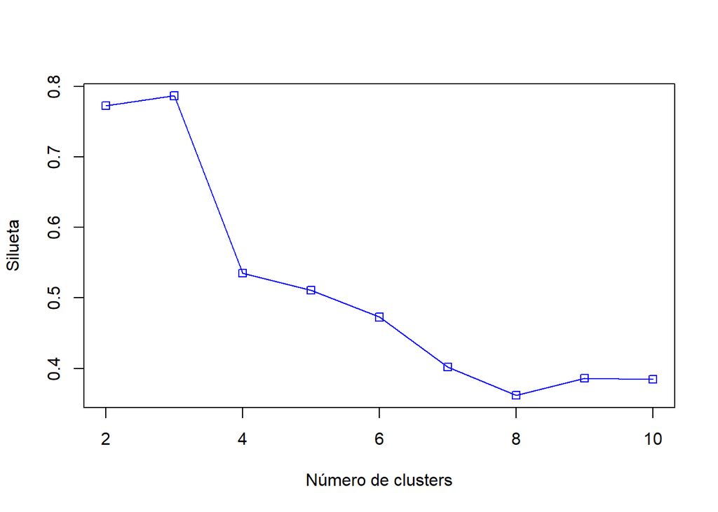

```r
plot(2:10,resultados[2:10],type="o",col="blue",pch=0,xlab="Número de clusters",ylab="Silueta")
```

Según los resultados obtenidos a partir de este método observamos que el número de clusteres óptimo parece ser 3 y muy de cerca le siguen 2 clusteres. Pasamos a realizar otra prueba para comparar los resultados.

Aplicamos a continuación el método del codo.

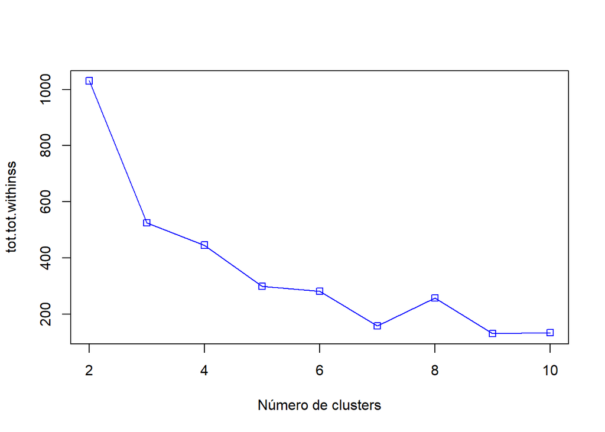

```r
set.seed(3)
resultados <- rep(0, 10)
for (i in c(2,3,4,5,6,7,8,9,10))
{
  fit           <- kmeans(x_scale, i)
  resultados[i] <- fit$tot.withinss
}
plot(2:10,resultados[2:10],type="o",col="blue",pch=0,xlab="Número de clusters",ylab="tot.tot.withinss")
```

En este caso, coincidiendo con el método anterior, el número óptimo de clústers es 3 que es cuando la curva comienza a estabilizarse.

Continuamos con el estudio del valor óptimo de clusters. En este caso sabemos que se trata de 3 clusters pero lo habitual es no conocer este número.

Utilizaremos a continuación la función kmeansruns que ejecuta el algoritmo kmeans con un conjunto de valores, para después seleccionar el valor del número de clústers que mejor funcione de acuerdo a dos criterios: la silueta media (“asw”) y Calinski-Harabasz (“ch”).

```r
if (!require('fpc')) install.packages('fpc')
library(fpc)

set.seed(3)
fit_ch  <- kmeansruns(x_scale, krange = 1:10, criterion = "ch")
fit_asw <- kmeansruns(x_scale, krange = 1:10, criterion = "asw")
```

Mostramos el resultado obtenido para todos los valores de k usando ambos criterios:

```r
fit_ch$bestk
```

```
## [1] 6
```

```r
fit_asw$bestk
```

```
## [1] 3
```

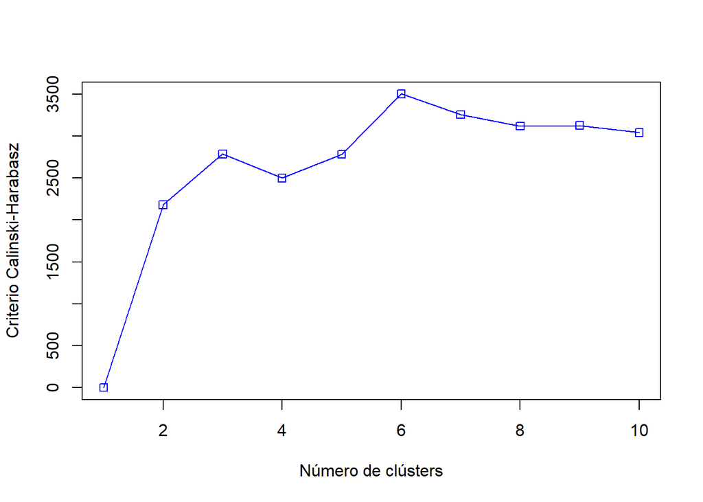

```r
plot(1:10,fit_ch$crit,type="o",col="blue",pch=0,xlab="Número de clústers",ylab="Criterio Calinski-Harabasz")
```

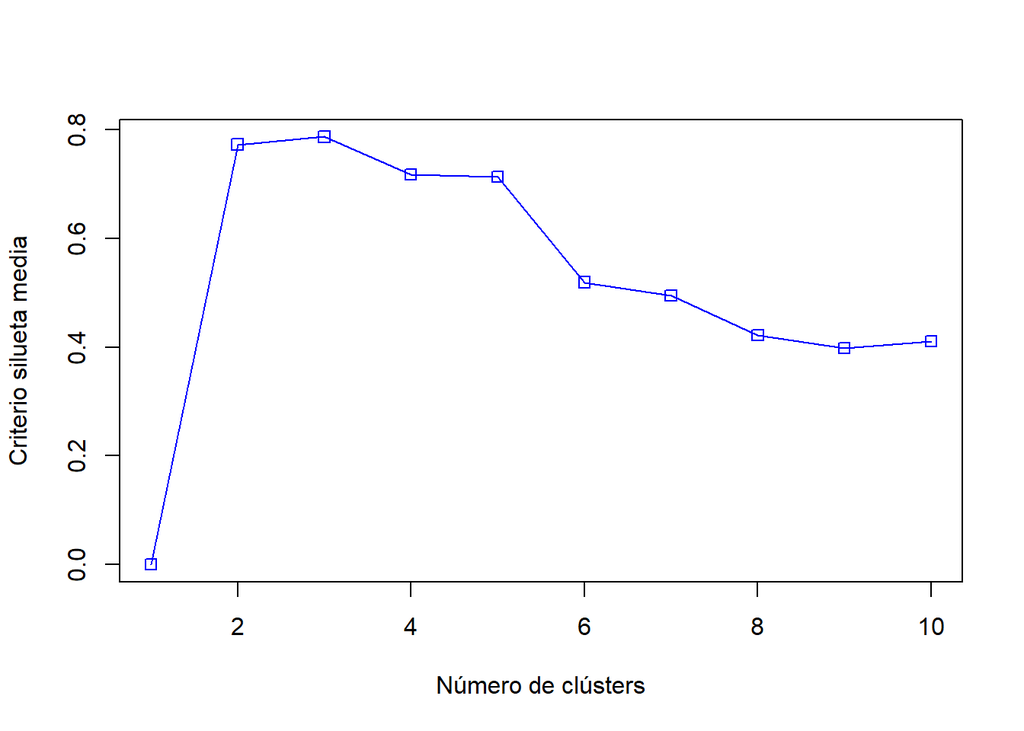

```r
plot(1:10,fit_asw$crit,type="o",col="blue",pch=0,xlab="Número de clústers",ylab="Criterio silueta media")
```

Con el criterio de la silueta media se obtienen tres clústers y con el criterio de Calinski-Harabasz se obtienen 6.

En este caso y puesto que de los métodos utilizados tres clústers ha sido el valor óptimo en la mayoría de ellos optaremos por tomar este valor para realizar nuestro algoritmo de kmeans.

A continuación estudiamos cómo se ha comportado kmeans en el caso de pedirle 3 clústers. Para eso comparamos visualmente los campos dos a dos, con el valor real que sabemos está almacenado en el campo “species” del dataset original.

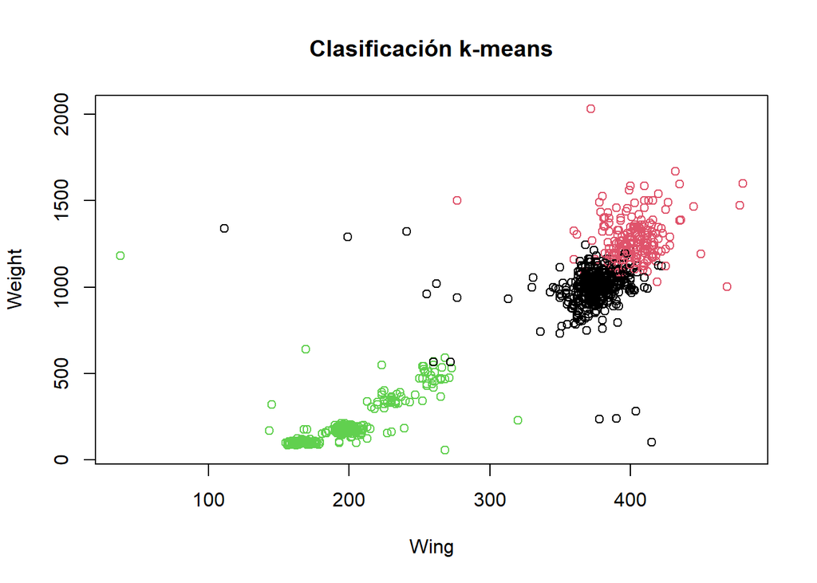

```r
set.seed(3)
Hawks3clusters <- kmeans(x_scale, 3)

# Weight y Wing
plot(x[c(1,2)], col=Hawks3clusters$cluster, main="Clasificación k-means")
```

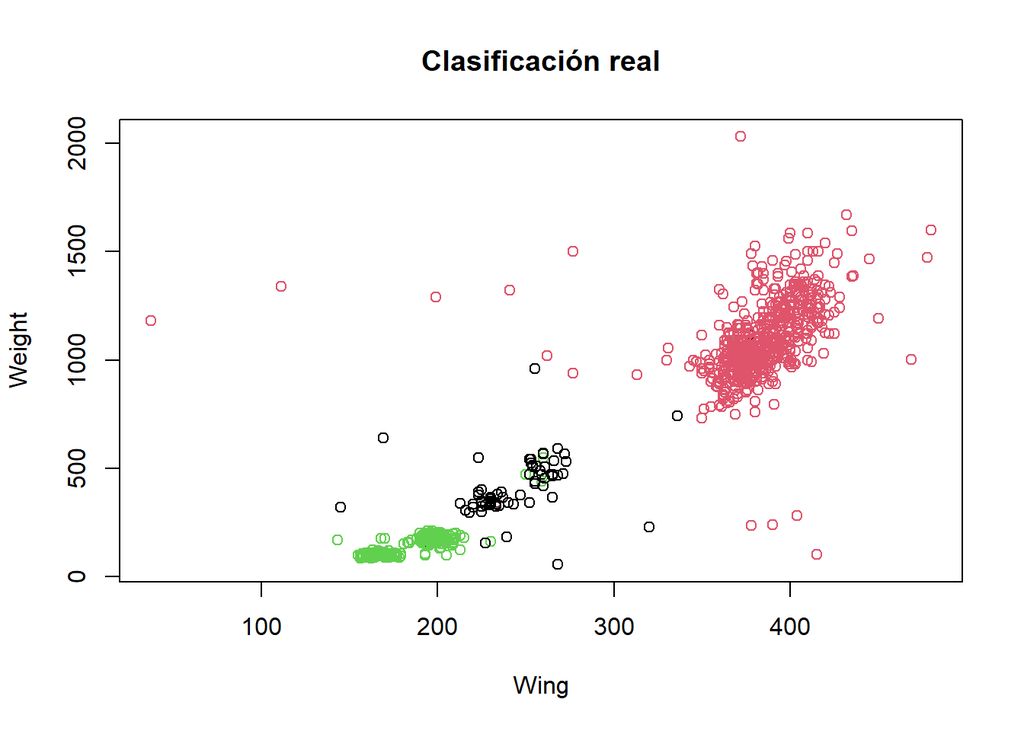

```r
plot(Hawks[c(10,11)], col=as.factor(Hawks$Species), main="Clasificación real")
```

Observamos que a pesar que “Weight” y “Wing” podrían ser buenos indicadores para diferenciar a las tres especies, el algoritmo de kmeans confunde una de las especies asignándola incorrectamente.

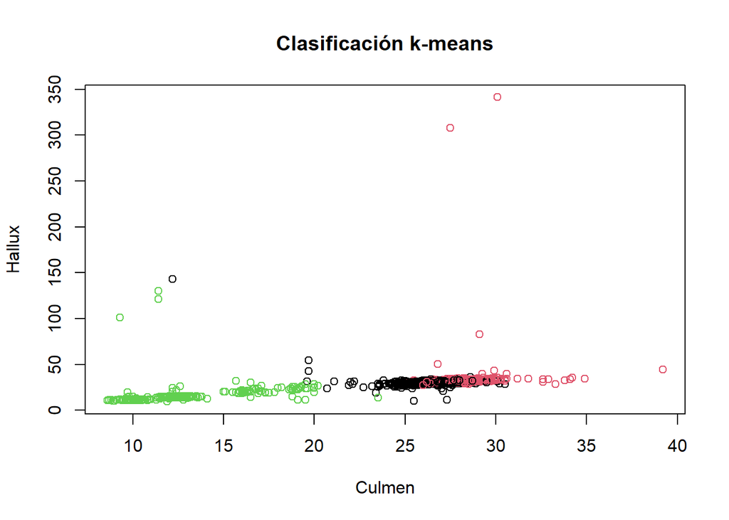

```r
# Hallux y Culmen
plot(x[c(3,4)], col=Hawks3clusters$cluster, main="Clasificación k-means")
```

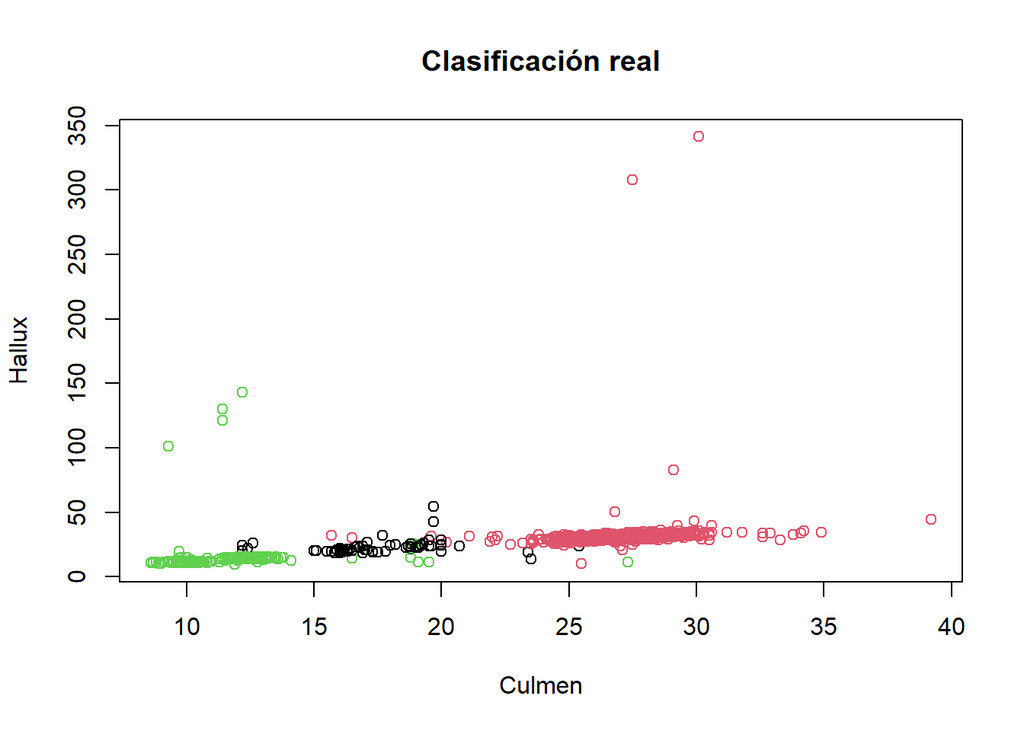

```r
plot(Hawks[c(12,13)], col=as.factor(Hawks$Species), main="Clasificación real")
```

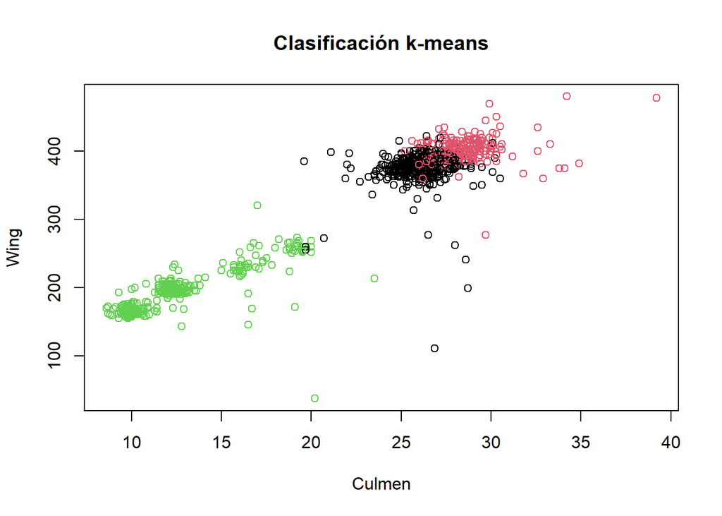

```r
# Culmen y Wing
plot(x[c(3,1)], col=Hawks3clusters$cluster, main="Clasificación k-means")
```

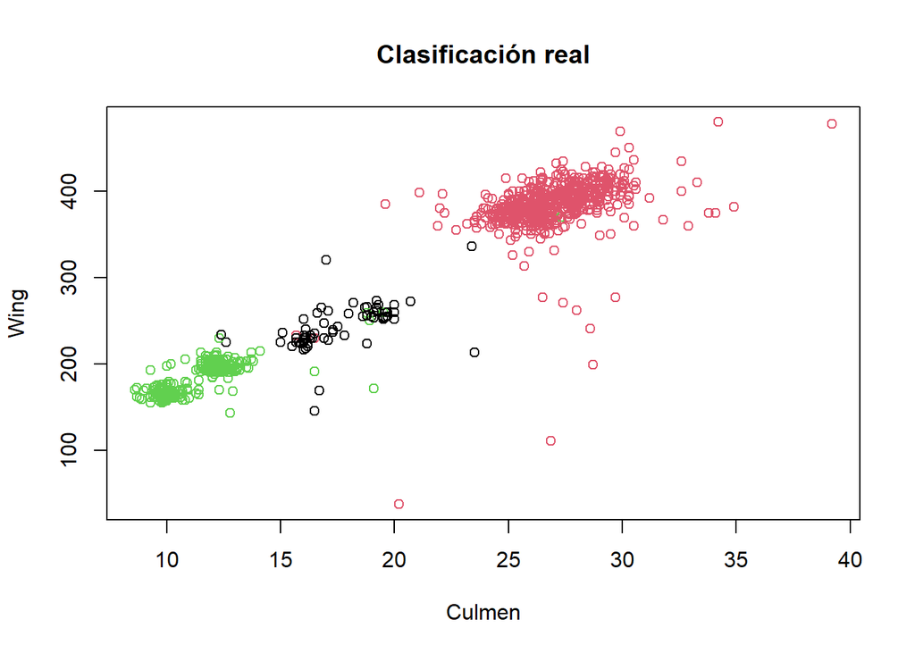

```r
plot(Hawks[c(12,10)], col=as.factor(Hawks$Species), main="Clasificación real")
```

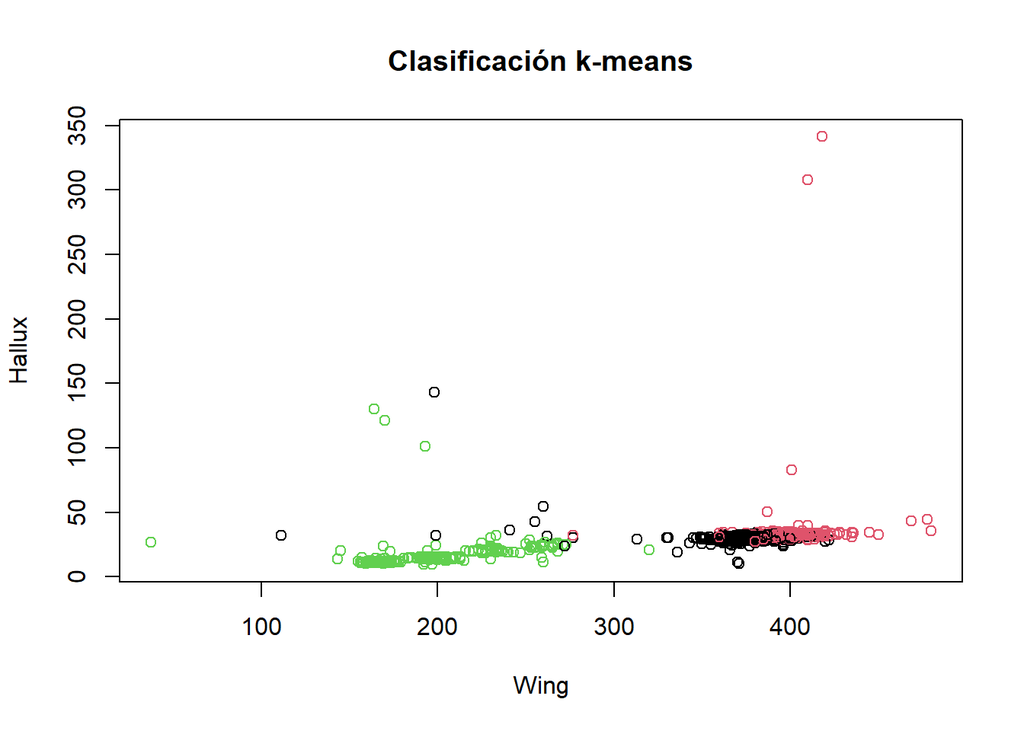

```r
# Hallux y Wing
plot(x[c(1,4)], col=Hawks3clusters$cluster, main="Clasificación k-means")
```

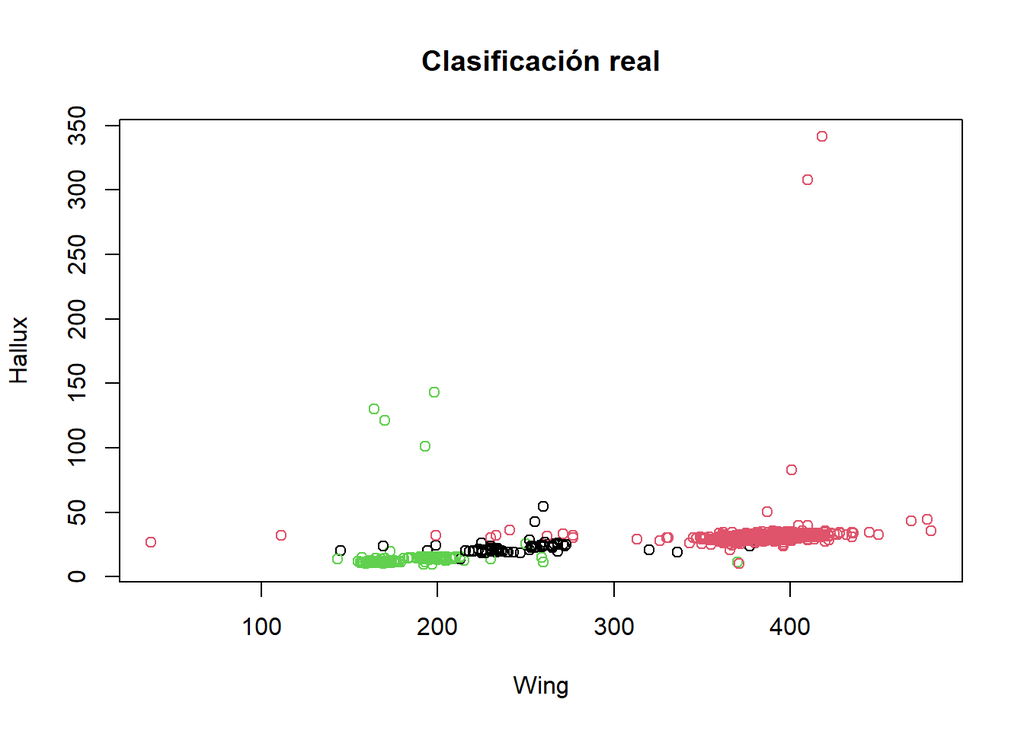

```r
plot(Hawks[c(10,13)], col=as.factor(Hawks$Species), main="Clasificación real")
```

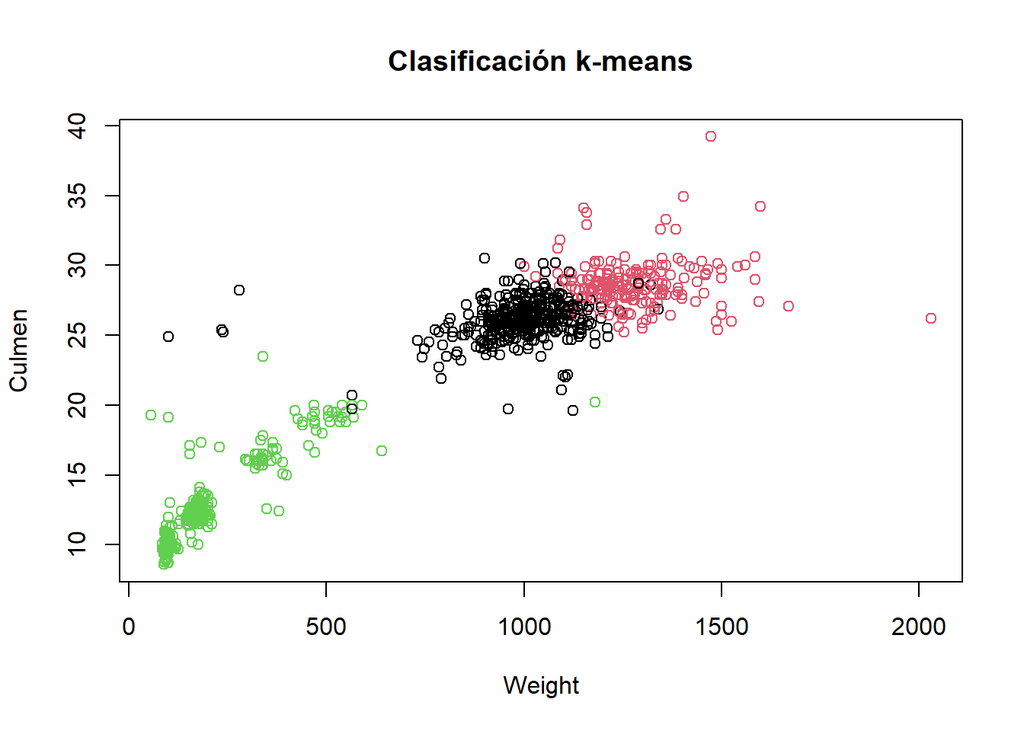

```r
# Culmen y Weight
plot(x[c(2,3)], col=Hawks3clusters$cluster, main="Clasificación k-means")
```

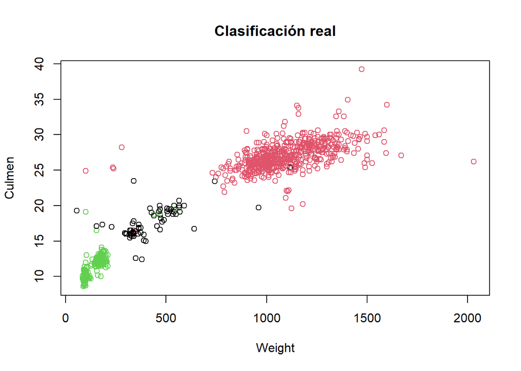

```r
plot(Hawks[c(11,12)], col=as.factor(Hawks$Species), main="Clasificación real")
```

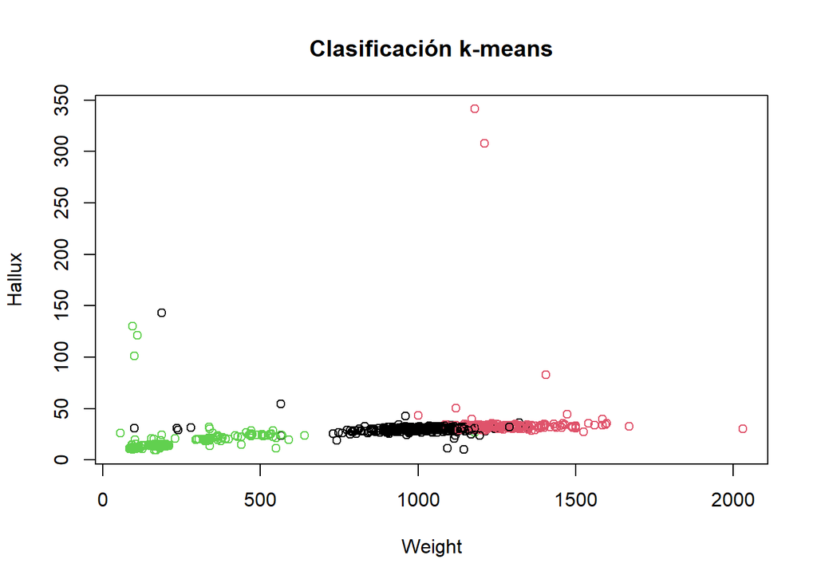

```r
# Hallux y Weight
plot(x[c(2,4)], col=Hawks3clusters$cluster, main="Clasificación k-means")
```

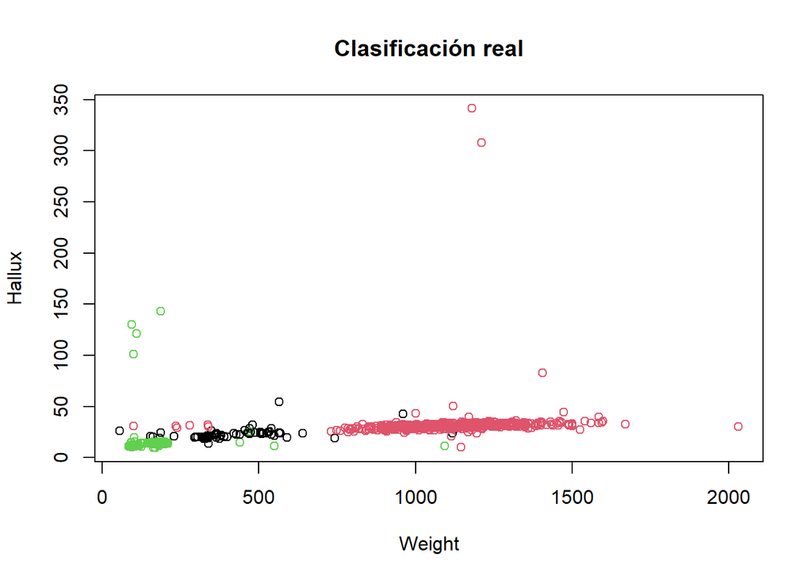

```r
plot(Hawks[c(11,13)], col=as.factor(Hawks$Species), main="Clasificación real")
```

Las conclusiones a las que se llegan a partir de los gráficos anteriores son las siguientes:

- En general las variables son buenos indicadores ya que los tres clústers se pueden observar visualmente separados en la clasificación real.
- A pesar del punto anterior el algoritmo tiene dificultades para identificar uno de los clústers y no devuelve los resultados esperados.

Sería una buena idea añadir diferentes variables del conjunto de datos para comparar los resultados obtenidos y tratar de obtener un algoritmo con mejores resultados.

## 0.2 Ejercicio 2

### 0.2.1 Enunciado

Con el juego de datos proporcionado realiza un estudio similar al del ejemplo 2.

- 20%. Se aplican lo algoritmos DBSCAN y OPTICS de forma correcta.
- 25%. Se prueban con diferentes valores de eps.
- 25%. Se obtiene una medida de lo bueno que es el agrupamiento.
- 20%. Se describen e interpretan los diferentes clusters obtenidos.
- 10%. Se presenta el código y es fácilmente reproducible.

### 0.2.2 Métodos basados en densidad: DBSCAN y OPTICS

Probaremos a continuación con los algoritmos DBSCAN y OPTICS, son métodos de clustering que permiten la generación de grupos no radiales (a diferencia de k-means).

```r
if (!require('dbscan')) install.packages('dbscan')
library(dbscan)
```

A continuación llamamos a la función optics fijando el criterior de vecindad en 10 y dejando el parámetro eps con su valor por defecto.

```r
res <- optics(x_scale, minPts = 10)
res
```

```
## OPTICS ordering/clustering for 891 objects.
## Parameters: minPts = 10, eps = 16.7418480888497, eps_cl = NA, xi = NA
## Available fields: order, reachdist, coredist, predecessor, minPts, eps,
##                   eps_cl, xi
```

Observamos el valor de eps que devuelve el algoritmo, eps se trata del límite superior del tamaño de la vecindad épsilon.

A continuación obtenemos el orden de los datos en función de su distancia de alcanzabilidad.

```r
res$order
```

[output not shown]

[output cut: 35 more lines]

A continuación observamos el diagrama de alcanzabilidad (reachability plot) en el que se aprecia la distancia de alcanzabilidad de cada punto.

Las cimas indican outliers. Observamos que existen muchos en la última agrupación.

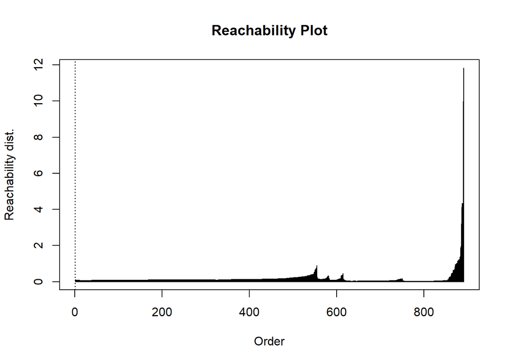

```r
### Gráfica de alcanzabilidad
plot(res)
```

A continuación modificamos el límite del eje de las ordenadas para observar mejor el resto de agrupaciones.

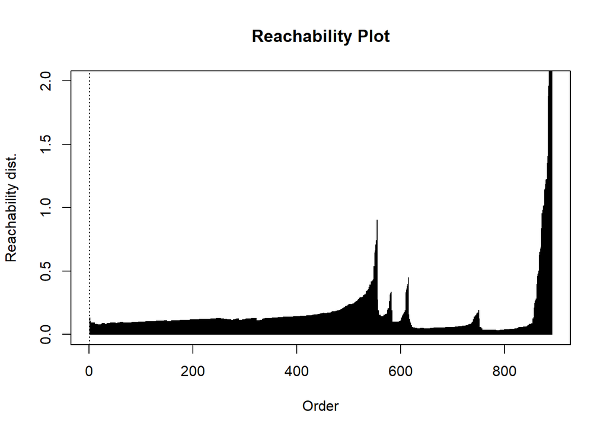

```r
plot(res, ylim=c(0,2))
```

Observamos que el algoritmo ha realizado entre 4 y 5 agrupaciones de los datos.

Otra posible representación del diagrama de alcanzabilidad es la siguiente:

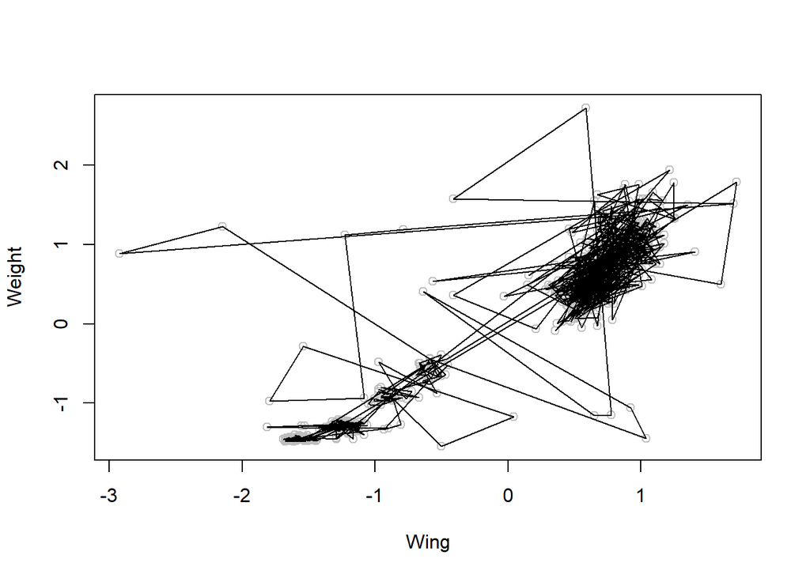

```r
### Dibujo de las trazas que relacionan puntos
plot(x_scale, col = "grey")
polygon(x_scale[res$order,])
```

En este caso visualmente podríamos separar en 3 o 4 agrupaciones y se observa una agrupación bastante más densa que el resto.

A continuación vamos a extraer una agrupación de la ordenación realizada por OPTICS similar a lo que DBSCAN hubiera generado estableciendo el parámetro eps. Se van a estudiar los resultados en caso de modificar el valor de eps_cl. Este valor se utiliza para determinar el número de clústeres, se calcula como un porcentaje de la distancia máxima de alcance en los datos.

En primer lugar probaremos con eps_cl = 0.065

```r
### Extracción de un clustering DBSCAN cortando la alcanzabilidad en el valor eps_cl
resdb <- extractDBSCAN(res, eps_cl = .065)
resdb
```

```
## OPTICS ordering/clustering for 891 objects.
## Parameters: minPts = 10, eps = 16.7418480888497, eps_cl = 0.065, xi = NA
## The clustering contains 2 cluster(s) and 706 noise points.
##
##   0   1   2
## 706  93  92
##
## Available fields: order, reachdist, coredist, predecessor, minPts, eps,
##                   eps_cl, xi, cluster
```

```r
### Extracción de un clustering DBSCAN cortando la alcanzabilidad en el valor eps_cl
resdb <- extractDBSCAN(res, eps_cl = 0.4)
resdb
```

```
## OPTICS ordering/clustering for 891 objects.
## Parameters: minPts = 10, eps = 16.7418480888497, eps_cl = 0.4, xi = NA
## The clustering contains 3 cluster(s) and 41 noise points.
##
##   0   1   2   3
##  41 542  60 248
##
## Available fields: order, reachdist, coredist, predecessor, minPts, eps,
##                   eps_cl, xi, cluster
```

A simple vista parece más razonable, vamos a visualizar el diagrama de alcanzabilidad.

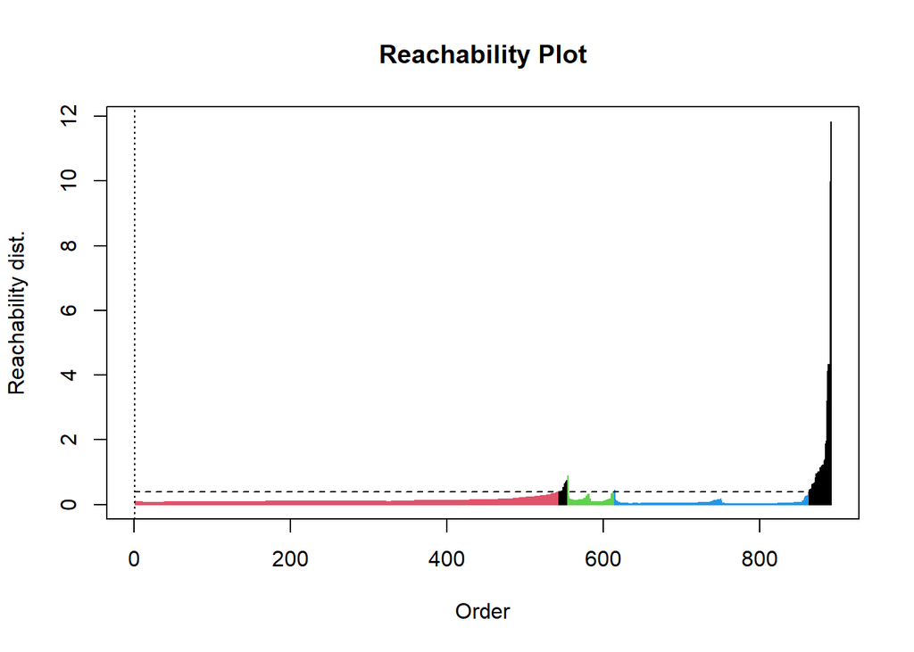

```r
plot(resdb) ## negro indica ruido
```

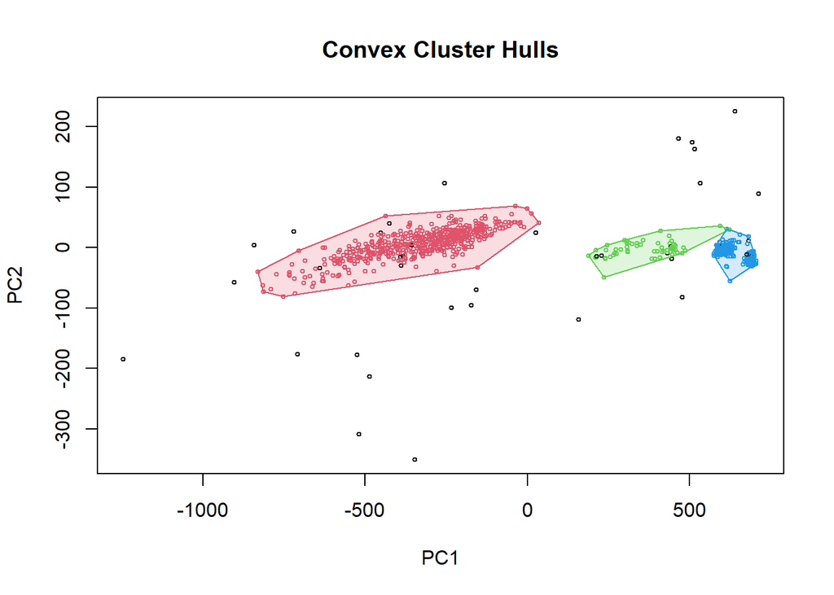

```r
hullplot(x, resdb)
```

A continuación comprobamos de que manera ha clasificado los datos el algoritmo según la clasificación real.

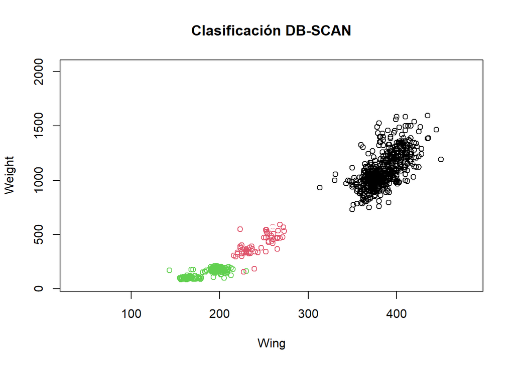

```r
# Wing y Weight
# Gráfico DB-SCAN
plot(x[c(1,2)], col=resdb$cluster, main="Clasificación DB-SCAN")
```

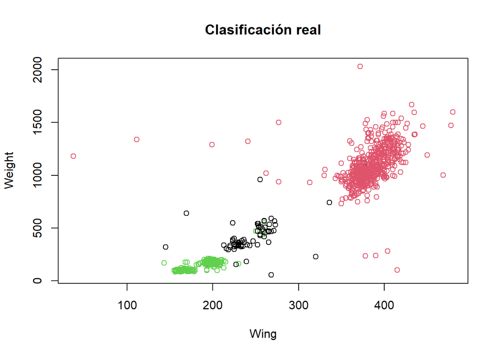

```r
# Gráfico de clasificación real
plot(Hawks[c(10,11)], col=as.factor(Hawks$Species), main="Clasificación real")
```

Observamos que ha eliminado los valores extremos y que ha identificado correctamente los tres clústers presentes en el conjunto de los datos.

## 0.3 Ejercicio 3

### 0.3.1 Enunciado

Realiza una comparativa de los métodos k-means y DBSCAN.

- 35%. Se comparan los resultados obtenidos en k-means y DBSCAN.
- 35%. Se mencionan pros y contras de ambos algoritmos
- 30%. Se exponen la conclusiones del trabajo

### 0.3.2 Conclusión

En primer lugar se ha utilizado el algoritmo k-means, que es un algoritmo de clasificación no supervisada, el principal inconveniente de este algoritmo es que se necesita fijar previamente el número de clústers. Lo habitual es no conocerlo por lo que es necesario realizar un estudio previo para determinarlo.

Hemos utilizado diferentes criterios para estudiar el valor ótimo de clústers. Se han realizado dichas pruebas con los valores de k desde 2 hasta 10. Según el método de la silueta media y según el método del codo el valor óptimo de clústers es 3. En cambio el criterio de Calinski-Harabasz ha optado por 6 clústers. Puesto que 3 clústers ha sido la opción óptima en la mayoría de pruebas se ha decidido realizar el modelo con este número.

El modelo de k-means con 3 clústers se ha evaluado visualizando los resultados de las variables de dos en dos. Hemos podido observar que si bien clasifica bastante bien dos de los clústers el tercero no es capaz de identificarlo correctamente.

Los modelos de clustering basados en la densidad más conocidos son DBSCAN y OPTICS. Este tipo de algoritmos se especializan en identificar zonas de alta concentración de observaciones separadas entre sí por zonas con menor densidad de observaciones.

La ventaja de estos algoritmos es que no es necesario identificar el número de clústers previamente. El algoritmo que mejor ha resultado ha sido DBSCAN. El diagrama DBSCAN con eps_cl = 0.4 ha conseguido muy buenos resultados. Se ha observado en la gráfica como éste elimina los valores outliers y ha identificado casi sin error los tres clústers del data set real.

Los motivos por los que ha funcionado mejor DBSCAN que el algoritmo k-means podrían ser lo siguientes:

- DBSCAN es un algoritmo de clustering basado en la densidad que agrupa puntos de datos en regiones densas. En el juego de datos (Hawks) este algoritmo tiende a funcionar mejor por la densidad de sus agrupamientos.
- DBSCAN identifica automáticamente el número de clústers y asigna puntos de datos a éstos en función de su densidad.
- K-means incluye los valores outliers en un clúster incluso si no pertenecen a ninguno. DBSCAN, por otro lado, puede identificarlos.
- K-means es adecuado para identificar clústers esféricos y bien separados, mientras que DBSCAN es más adecuado para identificar clústers de formas arbitrarias y no necesariamente separados.